# Vehicle Characteristics and Highway Fuel Efficiency

Author

Arnav Bhatia

Published

October 25, 2026

# Introduction

Fuel efficiency is an important characteristic of passenger vehicles because it affects fuel costs, energy consumption, and environmental impact. Vehicle fuel efficiency may be influenced by several design characteristics, including engine displacement, vehicle class, transmission type, and drivetrain. Larger engines generally consume more fuel, while drivetrain systems may introduce additional differences in efficiency.

This report analyzes the `mpg` dataset included with the `ggplot2` R package. The dataset contains fuel-economy measurements collected by the United States Environmental Protection Agency for vehicle models manufactured in 1999 and 2008. Each observation represents one vehicle configuration.

The primary research question is:

**How is engine displacement associated with highway fuel efficiency, and does highway fuel efficiency differ across drivetrain types?**

The analysis also considers whether fuel efficiency differs by vehicle class and transmission type.

# Data Preparation

The original dataset was accessed directly from the `ggplot2` package using `ggplot2::mpg`. Because the dataset is distributed with the package, no separate data file was required.

The data preparation process included the following steps:

1. Manufacturer, model, year, cylinder count, and vehicle class were converted to categorical variables.
2. Detailed transmission descriptions were grouped into automatic and manual transmission categories.
3. Drivetrain codes were changed into descriptive labels.
4. Fuel-type codes were changed into descriptive labels.
5. A new variable, average miles per gallon, was calculated as the mean of city and highway fuel efficiency.
6. Variables were renamed to improve readability.

```r
quality_table <- data.frame(
  Measure = c(
    "Number of observations",
    "Number of variables",
    "Duplicate rows",
    "Missing values",
    "Unique manufacturers",
    "Unique vehicle classes"
  ),
  Value = c(
    nrow(vehicle_data),
    ncol(vehicle_data),
    sum(duplicated(vehicle_data)),
    sum(is.na(vehicle_data)),
    n_distinct(vehicle_data$manufacturer),
    n_distinct(vehicle_data$vehicle_class)
  )
)

kable(
  quality_table,
  caption = "Basic data-quality assessment",
  align = c("l", "r")
)
```

Basic data-quality assessment

| Measure | Value |
| --- | --- |
| Number of observations | 234 |
| Number of variables | 12 |
| Duplicate rows | 9 |
| Missing values | 0 |
| Unique manufacturers | 15 |
| Unique vehicle classes | 7 |

The prepared dataset contains 234 vehicle configurations and 12 variables. It includes 15 manufacturers and 7 vehicle classes. There are 0 missing values in the prepared dataset, so no imputation or removal of observations was required.

# Exploratory Analysis

## Characteristics of the Dataset

The main variables used in this analysis are shown below.

```r
variable_table <- data.frame(
  Variable = c(
    "manufacturer",
    "model",
    "year",
    "displ",
    "cylinders",
    "transmission",
    "drive_type",
    "vehicle_class",
    "city_mpg",
    "highway_mpg",
    "average_mpg"
  ),
  Description = c(
    "Vehicle manufacturer",
    "Vehicle model",
    "Model year",
    "Engine displacement in liters",
    "Number of engine cylinders",
    "Automatic or manual transmission",
    "Front-wheel, rear-wheel, or four-wheel drive",
    "Vehicle classification",
    "Estimated city miles per gallon",
    "Estimated highway miles per gallon",
    "Mean of city and highway miles per gallon"
  )
)

kable(
  variable_table,
  caption = "Variables included in the prepared dataset",
  align = c("l", "l")
)
```

Variables included in the prepared dataset

| Variable | Description |
| --- | --- |
| manufacturer | Vehicle manufacturer |
| model | Vehicle model |
| year | Model year |
| displ | Engine displacement in liters |
| cylinders | Number of engine cylinders |
| transmission | Automatic or manual transmission |
| drive_type | Front-wheel, rear-wheel, or four-wheel drive |
| vehicle_class | Vehicle classification |
| city_mpg | Estimated city miles per gallon |
| highway_mpg | Estimated highway miles per gallon |
| average_mpg | Mean of city and highway miles per gallon |

## Summary of Key Numeric Variables

```r
numeric_summary <- vehicle_data |>
  summarise(
    across(
      c(displ, city_mpg, highway_mpg, average_mpg),
      list(
        Minimum = ~min(.x),
        Mean = ~mean(.x),
        Median = ~median(.x),
        SD = ~sd(.x),
        Maximum = ~max(.x)
      )
    )
  ) |>
  tidyr::pivot_longer(
    cols = everything(),
    names_to = c("Variable", "Statistic"),
    names_pattern = "(.*)_(Minimum|Mean|Median|SD|Maximum)",
    values_to = "Value"
  ) |>
  tidyr::pivot_wider(
    names_from = Statistic,
    values_from = Value
  ) |>
  mutate(
    Variable = recode(
      Variable,
      displ = "Engine displacement (liters)",
      city_mpg = "City fuel efficiency (MPG)",
      highway_mpg = "Highway fuel efficiency (MPG)",
      average_mpg = "Average fuel efficiency (MPG)"
    ),
    across(where(is.numeric), ~round(.x, 2))
  )

kable(
  numeric_summary,
  caption = "Summary statistics for key numeric variables",
  align = c("l", "r", "r", "r", "r", "r")
)
```

Summary statistics for key numeric variables

| Variable | Minimum | Mean | Median | SD | Maximum |
| --- | --- | --- | --- | --- | --- |
| Engine displacement (liters) | 1.6 | 3.47 | 3.3 | 1.29 | 7.0 |
| City fuel efficiency (MPG) | 9.0 | 16.86 | 17.0 | 4.26 | 35.0 |
| Highway fuel efficiency (MPG) | 12.0 | 23.44 | 24.0 | 5.95 | 44.0 |
| Average fuel efficiency (MPG) | 10.5 | 20.15 | 20.5 | 5.05 | 39.5 |

Highway fuel efficiency ranges from 12 to 44 miles per gallon. The mean highway fuel efficiency is 23.4 MPG, compared with a mean city fuel efficiency of 16.9 MPG.

## Distribution of Highway Fuel Efficiency

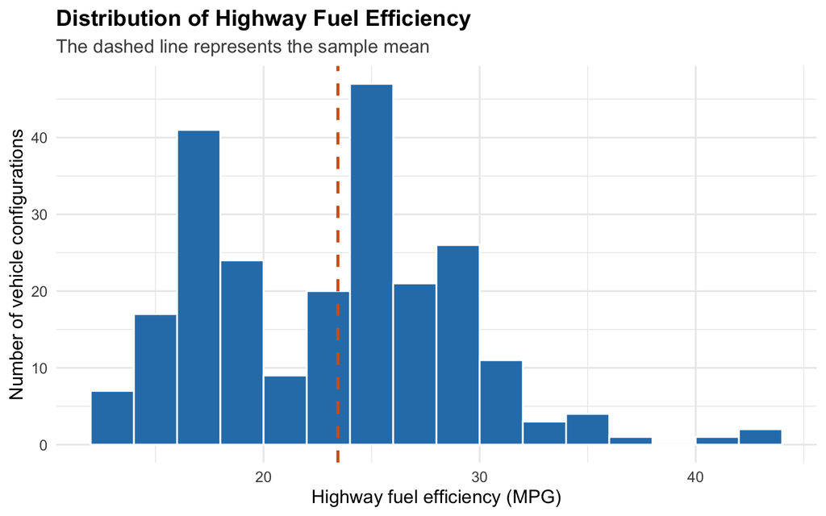

Distribution of highway fuel efficiency among vehicle configurations.

```r
ggplot(vehicle_data, aes(x = highway_mpg)) +
  geom_histogram(
    binwidth = 2,
    boundary = 0,
    color = "white",
    fill = "#2C7FB8"
  ) +
  geom_vline(
    xintercept = mean(vehicle_data$highway_mpg),
    color = "#D95F0E",
    linewidth = 1,
    linetype = "dashed"
  ) +
  labs(
    title = "Distribution of Highway Fuel Efficiency",
    subtitle = "The dashed line represents the sample mean",
    x = "Highway fuel efficiency (MPG)",
    y = "Number of vehicle configurations"
  )
```

The distribution is concentrated primarily between approximately 20 and 30 MPG. A smaller number of vehicle configurations have highway efficiency above 35 MPG.

## Vehicle Configurations by Class

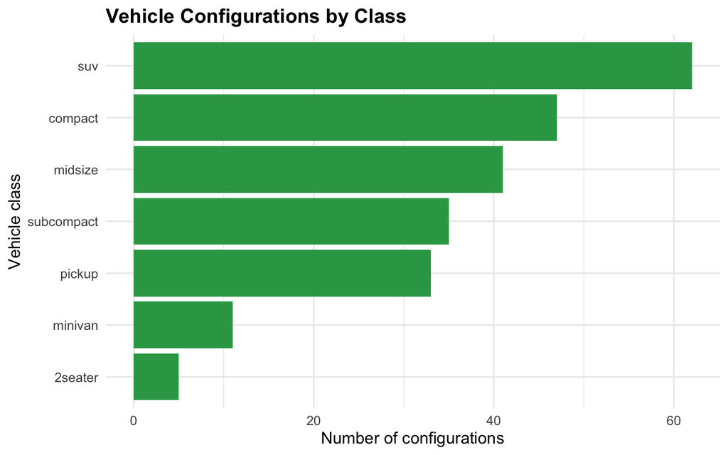

Number of vehicle configurations represented in each vehicle class.

```r
class_counts <- vehicle_data |>
  count(vehicle_class, sort = TRUE)

ggplot(
  class_counts,
  aes(x = reorder(vehicle_class, n), y = n)
) +
  geom_col(fill = "#31A354") +
  coord_flip() +
  labs(
    title = "Vehicle Configurations by Class",
    x = "Vehicle class",
    y = "Number of configurations"
  )
```

SUVs and compact vehicles are among the most frequently represented vehicle classes. Subcompact, midsize, pickup, minivan, and two-seater vehicles are also included.

# Preliminary Results

## Highway Fuel Efficiency by Drivetrain

```r
drive_summary <- vehicle_data |>
  group_by(drive_type) |>
  summarise(
    Vehicles = n(),
    `Mean highway MPG` = mean(highway_mpg),
    `SD highway MPG` = sd(highway_mpg),
    `Median highway MPG` = median(highway_mpg),
    `Minimum highway MPG` = min(highway_mpg),
    `Maximum highway MPG` = max(highway_mpg),
    .groups = "drop"
  ) |>
  mutate(
    across(
      c(
        `Mean highway MPG`,
        `SD highway MPG`,
        `Median highway MPG`
      ),
      ~round(.x, 1)
    )
  )

kable(
  drive_summary,
  caption = "Highway fuel efficiency by drivetrain",
  align = c("l", "r", "r", "r", "r", "r", "r")
)
```

Highway fuel efficiency by drivetrain

| drive_type | Vehicles | Mean highway MPG | SD highway MPG | Median highway MPG | Minimum highway MPG | Maximum highway MPG |
| --- | --- | --- | --- | --- | --- | --- |
| Front-wheel drive | 106 | 28.2 | 4.2 | 28 | 17 | 44 |
| Rear-wheel drive | 25 | 21.0 | 3.7 | 21 | 15 | 26 |
| Four-wheel drive | 103 | 19.2 | 4.1 | 18 | 12 | 28 |

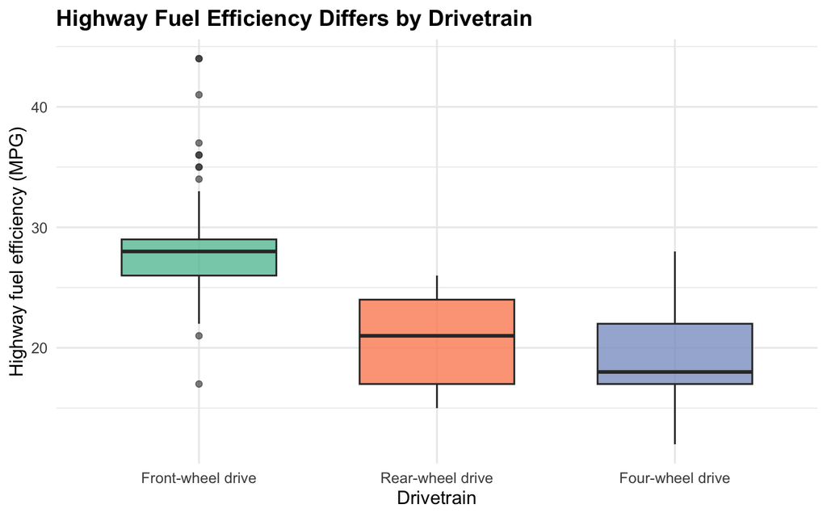

Highway fuel efficiency by drivetrain type.

```r
ggplot(
  vehicle_data,
  aes(x = drive_type, y = highway_mpg, fill = drive_type)
) +
  geom_boxplot(width = 0.65, alpha = 0.8, outlier.alpha = 0.6) +
  scale_fill_brewer(palette = "Set2", guide = "none") +
  labs(
    title = "Highway Fuel Efficiency Differs by Drivetrain",
    x = "Drivetrain",
    y = "Highway fuel efficiency (MPG)"
  )
```

Front-wheel-drive vehicles have the highest mean highway fuel efficiency in the dataset, while four-wheel-drive vehicles have the lowest mean. However, these unadjusted comparisons do not account for differences in engine displacement or vehicle composition across drivetrain categories.

## Engine Displacement and Highway Fuel Efficiency

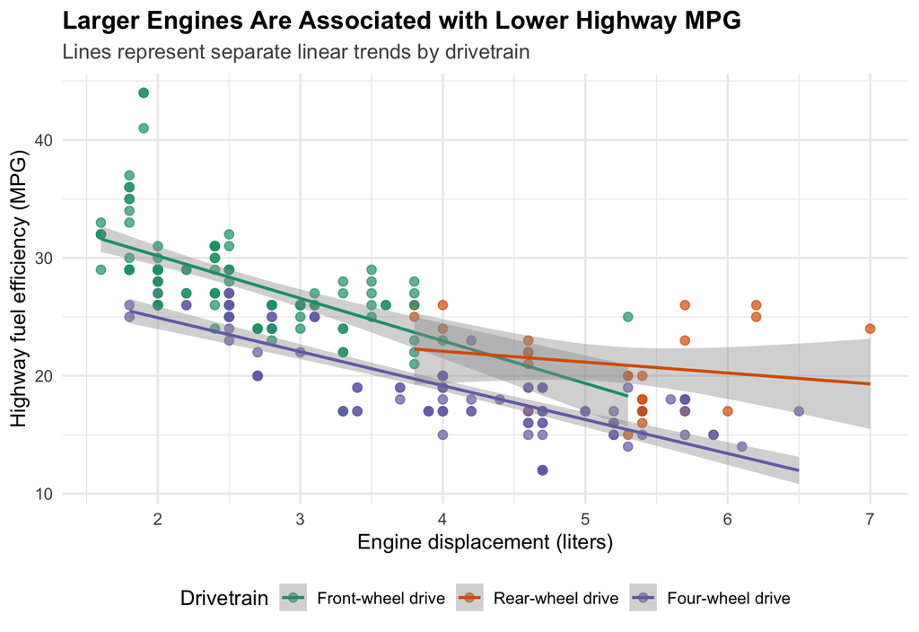

Relationship between engine displacement and highway fuel efficiency, stratified by drivetrain.

```r
ggplot(
  vehicle_data,
  aes(
    x = displ,
    y = highway_mpg,
    color = drive_type
  )
) +
  geom_point(size = 2.3, alpha = 0.7) +
  geom_smooth(
    method = "lm",
    se = TRUE,
    linewidth = 0.9
  ) +
  scale_color_brewer(palette = "Dark2") +
  labs(
    title = "Larger Engines Are Associated with Lower Highway MPG",
    subtitle = "Lines represent separate linear trends by drivetrain",
    x = "Engine displacement (liters)",
    y = "Highway fuel efficiency (MPG)",
    color = "Drivetrain"
  )
```

The scatterplot shows a clear negative relationship between engine displacement and highway fuel efficiency. Vehicles with larger engines generally achieve fewer highway miles per gallon. This pattern is visible within each drivetrain category, although the strength and location of the relationship vary.

```r
correlation_value <- cor(
  vehicle_data$displ,
  vehicle_data$highway_mpg
)

correlation_table <- data.frame(
  Variables = "Engine displacement and highway MPG",
  `Pearson correlation` = round(correlation_value, 3)
)

kable(
  correlation_table,
  caption = "Correlation between engine displacement and highway fuel efficiency",
  align = c("l", "r")
)
```

Correlation between engine displacement and highway fuel efficiency

| Variables | Pearson.correlation |
| --- | --- |
| Engine displacement and highway MPG | -0.766 |

The Pearson correlation between engine displacement and highway fuel efficiency is -0.766. This indicates a strong negative linear association: highway fuel efficiency tends to decrease as engine displacement increases.

## Linear Regression Analysis

A multiple linear regression model was used to estimate the association between engine displacement and highway fuel efficiency while accounting for drivetrain. The outcome was highway MPG, and the predictors were engine displacement and drivetrain category.

```r
fuel_model <- lm(
  highway_mpg ~ displ + drive_type,
  data = vehicle_data
)

model_coefficients <- summary(fuel_model)$coefficients |>
  as.data.frame()

model_table <- data.frame(
  Term = rownames(model_coefficients),
  Estimate = model_coefficients[, "Estimate"],
  `Standard error` = model_coefficients[, "Std. Error"],
  `p-value` = model_coefficients[, "Pr(>|t|)"],
  row.names = NULL,
  check.names = FALSE
) |>
  mutate(
    Term = recode(
      Term,
      "(Intercept)" = "Intercept",
      "displ" = "Engine displacement (per liter)",
      "drive_typeRear-wheel drive" =
        "Rear-wheel vs. front-wheel drive",
      "drive_typeFour-wheel drive" =
        "Four-wheel vs. front-wheel drive"
    ),
    Estimate = round(Estimate, 2),
    `Standard error` = round(`Standard error`, 2),
    `p-value` = format.pval(
      `p-value`,
      digits = 3,
      eps = 0.001
    )
  )

kable(
  model_table,
  caption = "Linear regression predicting highway fuel efficiency",
  align = c("l", "r", "r", "r")
)
```

Linear regression predicting highway fuel efficiency

| Term | Estimate | Standard error | p-value |
| --- | --- | --- | --- |
| Intercept | 35.62 | 0.63 | <0.001 |
| Engine displacement (per liter) | -2.91 | 0.22 | <0.001 |
| Rear-wheel vs. front-wheel drive | 0.47 | 0.89 | 0.601 |
| Four-wheel vs. front-wheel drive | -4.79 | 0.53 | <0.001 |

After accounting for drivetrain, a one-liter increase in engine displacement was associated with an estimated 2.91-MPG decrease in highway fuel efficiency. The model explained approximately 73.6% of the observed variation in highway MPG. The adjusted R-squared value was 0.732.

These findings describe associations within the dataset and should not be interpreted as proof that increasing engine displacement directly causes a specific reduction in fuel efficiency.

## Fuel Efficiency by Vehicle Class

```r
class_summary <- vehicle_data |>
  group_by(vehicle_class) |>
  summarise(
    Vehicles = n(),
    `Mean city MPG` = mean(city_mpg),
    `Mean highway MPG` = mean(highway_mpg),
    .groups = "drop"
  ) |>
  arrange(desc(`Mean highway MPG`)) |>
  mutate(
    across(
      c(`Mean city MPG`, `Mean highway MPG`),
      ~round(.x, 1)
    )
  )

kable(
  class_summary,
  caption = "Mean fuel efficiency by vehicle class",
  align = c("l", "r", "r", "r")
)
```

Mean fuel efficiency by vehicle class

| vehicle_class | Vehicles | Mean city MPG | Mean highway MPG |
| --- | --- | --- | --- |
| compact | 47 | 20.1 | 28.3 |
| subcompact | 35 | 20.4 | 28.1 |
| midsize | 41 | 18.8 | 27.3 |
| 2seater | 5 | 15.4 | 24.8 |
| minivan | 11 | 15.8 | 22.4 |
| suv | 62 | 13.5 | 18.1 |
| pickup | 33 | 13.0 | 16.9 |

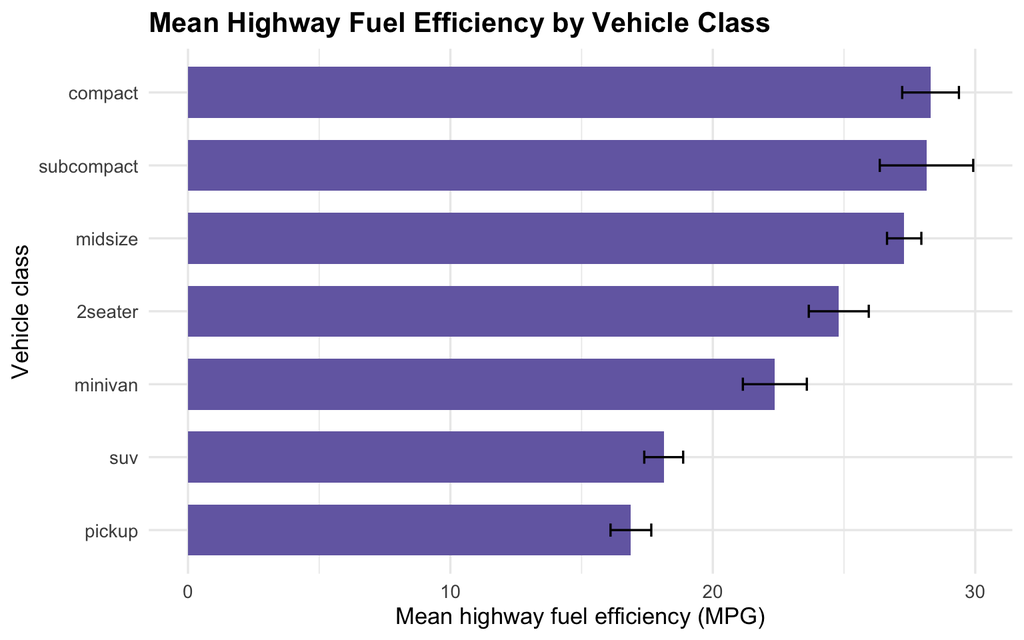

Mean highway fuel efficiency by vehicle class. Error bars represent 95% confidence intervals.

```r
class_plot_data <- vehicle_data |>
  group_by(vehicle_class) |>
  summarise(
    mean_highway_mpg = mean(highway_mpg),
    standard_error = sd(highway_mpg) / sqrt(n()),
    lower_ci = mean_highway_mpg - 1.96 * standard_error,
    upper_ci = mean_highway_mpg + 1.96 * standard_error,
    .groups = "drop"
  )

ggplot(
  class_plot_data,
  aes(
    x = reorder(vehicle_class, mean_highway_mpg),
    y = mean_highway_mpg
  )
) +
  geom_col(fill = "#756BB1", width = 0.7) +
  geom_errorbar(
    aes(ymin = lower_ci, ymax = upper_ci),
    width = 0.18
  ) +
  coord_flip() +
  labs(
    title = "Mean Highway Fuel Efficiency by Vehicle Class",
    x = "Vehicle class",
    y = "Mean highway fuel efficiency (MPG)"
  )
```

Compact, subcompact, and midsize vehicles have relatively high mean highway fuel efficiency. SUVs and pickup trucks have lower average highway efficiency, which may partly reflect their larger engines and heavier vehicle designs.

## Fuel Efficiency by Transmission Type

```r
transmission_summary <- vehicle_data |>
  group_by(transmission) |>
  summarise(
    Vehicles = n(),
    `Mean city MPG` = mean(city_mpg),
    `Mean highway MPG` = mean(highway_mpg),
    `Mean engine displacement` = mean(displ),
    .groups = "drop"
  ) |>
  mutate(
    across(where(is.numeric) & !Vehicles, ~round(.x, 1))
  )

kable(
  transmission_summary,
  caption = "Vehicle characteristics by transmission type",
  align = c("l", "r", "r", "r", "r")
)
```

Vehicle characteristics by transmission type

| transmission | Vehicles | Mean city MPG | Mean highway MPG | Mean engine displacement |
| --- | --- | --- | --- | --- |
| Automatic | 157 | 16.0 | 22.3 | 3.7 |
| Manual | 77 | 18.7 | 25.8 | 3.0 |

Manual-transmission vehicles have a somewhat higher mean highway MPG in this dataset. This comparison is descriptive and may be influenced by differences in engine size, vehicle class, manufacturer, and model year.

# Conclusion

This analysis found a strong negative association between engine displacement and highway fuel efficiency. Vehicle configurations with larger engines generally achieved fewer highway miles per gallon, even after drivetrain was included in a multiple linear regression model.

Fuel efficiency also varied across drivetrain and vehicle-class categories. Front-wheel-drive vehicles had the highest mean highway MPG, while four-wheel-drive vehicles had the lowest. Compact and subcompact vehicles were among the most fuel-efficient classes, whereas SUVs and pickup trucks had lower average highway MPG.

Several limitations should be considered. The dataset includes only vehicle configurations from 1999 and 2008, so the results may not represent newer vehicles. The observations are also not a random sample of all vehicles on the road. In addition, the regression model does not include every characteristic that could affect fuel efficiency, such as vehicle weight, horsepower, or aerodynamic design. Therefore, the findings should be interpreted as descriptive associations rather than causal effects.

Overall, the analysis suggests that engine size, drivetrain, and vehicle class are important characteristics associated with highway fuel efficiency.